# analysis_racingtime

Author

Christian Magelssen

This quarto file analyzes the racing times. Every analysis, including models and plots, reported in the paper related to racing times can be found here. We start by loading the necessary packages and a custom function for data analysis.

```r
options(scipen = 999)

# Load in packages
library(tidyverse) # For data manipulation
library(lme4) # For statistical modelling
library(lmerTest) # For statistical modelling
library(ggpubr) # To create publication-ready figures
library(easystats) # For model diagnostics
library(emmeans) # For estimating marginal effects
library(ggbeeswarm) # For
library(patchwork)
library(cowplot)
library(broom.mixed)
library(stringr)
```

```r
#source("code/report_statistics.R") # This is a custom function that summarizes the test statistics, format it to latex code that can be included in latex
#source("code/plot_functions.R") # This is a custom function that plot the estimates from the emmeans model
```

Next, we load in the data

```r
# We load the data
d <- read_csv("../../data/data_analysis/data_analysis.csv")
d
```

```
# A tibble: 3,067 × 16
   skigroup skier treatment session  trial strategy best_strategy_first
   <chr>    <dbl> <chr>     <chr>    <dbl> <chr>    <chr>
 1 a            1 slfc      baseline     1 ns       d
 2 a            1 slfc      baseline     2 ns       d
 3 a            1 slfc      baseline     3 ns       d
 4 a            1 slfc      baseline     4 ns       d
 5 a            1 slfc      block1       5 a        d
 6 a            1 slfc      block1       6 c        d
 7 a            1 slfc      block1       7 b        d
 8 a            1 slfc      block1       8 d        d
 9 a            1 slfc      block1       9 d        d
10 a            1 slfc      block1      10 c        d
# ℹ 3,057 more rows
# ℹ 9 more variables: best_strategy_last <chr>, theory_best <chr>,
#   racingtime <dbl>, chose_best_strategy <dbl>, chose_theoretical_best <dbl>,
#   regret_a <dbl>, regret_b <dbl>, regret_c <dbl>, regret_d <dbl>
```

# Acquisition

## Select data

The acquisition phase of the experiment covers Block 1 (forced exploration), and Block 2 and Block 3 (free-choice). Therefore, we filter those.

```r
d_acquisition <- filter(d, session == "block1" | session == "block2" | session == "block3")
d_acquisition
```

```
# A tibble: 1,920 × 16
   skigroup skier treatment session trial strategy best_strategy_first
   <chr>    <dbl> <chr>     <chr>   <dbl> <chr>    <chr>
 1 a            1 slfc      block1      5 a        d
 2 a            1 slfc      block1      6 c        d
 3 a            1 slfc      block1      7 b        d
 4 a            1 slfc      block1      8 d        d
 5 a            1 slfc      block1      9 d        d
 6 a            1 slfc      block1     10 c        d
 7 a            1 slfc      block1     11 b        d
 8 a            1 slfc      block1     12 a        d
 9 a            1 slfc      block2     13 c        d
10 a            1 slfc      block2     14 c        d
# ℹ 1,910 more rows
# ℹ 9 more variables: best_strategy_last <chr>, theory_best <chr>,
#   racingtime <dbl>, chose_best_strategy <dbl>, chose_theoretical_best <dbl>,
#   regret_a <dbl>, regret_b <dbl>, regret_c <dbl>, regret_d <dbl>
```

## Coding contrasts

The next step is to set up the treatment contrasts. Instead of using the Intercept as the reference level, we code the Intercept to represent the Grand Mean. This coding scheme is known as simple coding (https://stats.oarc.ucla.edu/r/library/r-library-contrast-coding-systems-for-categorical-variables/).”

```r
# Simple code treatment
d_acquisition <- mutate(d_acquisition, treatment=as.factor(treatment)) # Turn it into factor
treatmentcoding <- contr.treatment(3)
matrix <- matrix(rep(1/3, 6), ncol=2)
treatment_simplecoded <- treatmentcoding - matrix
contrasts(d_acquisition$treatment) <- treatment_simplecoded

# Simple code session
d_acquisition <- mutate(d_acquisition, session=as.factor(session))
treatmentcoding <- contr.treatment(3)
matrix <- matrix(rep(1/3, 6), ncol=2)
session_simplecoded <- treatmentcoding - matrix
contrasts(d_acquisition$session) <- session_simplecoded
```

## Models

```r
# This model was singular
model_racingtime_acquisition_1 <- lmer(racingtime ~ session * treatment + (1 + session | skigroup/skier), REML=FALSE, data=d_acquisition)
# This model converged and was not singular
model_racingtime_acquisition_2 <- lmer(racingtime ~ session * treatment + (1 | skigroup) + (1 + session | skigroup:skier), REML=FALSE, data=d_acquisition)

anova(model_racingtime_acquisition_2)
```

```
Type III Analysis of Variance Table with Satterthwaite's method
                   Sum Sq Mean Sq NumDF  DenDF  F value                Pr(>F)
session           17.6096  8.8048     2 95.409 209.1435 < 0.00000000000000022
treatment          0.0634  0.0317     2 85.732   0.7525             0.4742571
session:treatment  1.0485  0.2621     4 95.418   6.2264             0.0001703

session           ***
treatment
session:treatment ***
---
Signif. codes:  0 '***' 0.001 '**' 0.01 '*' 0.05 '.' 0.1 ' ' 1
```

We check diagnostics of this model

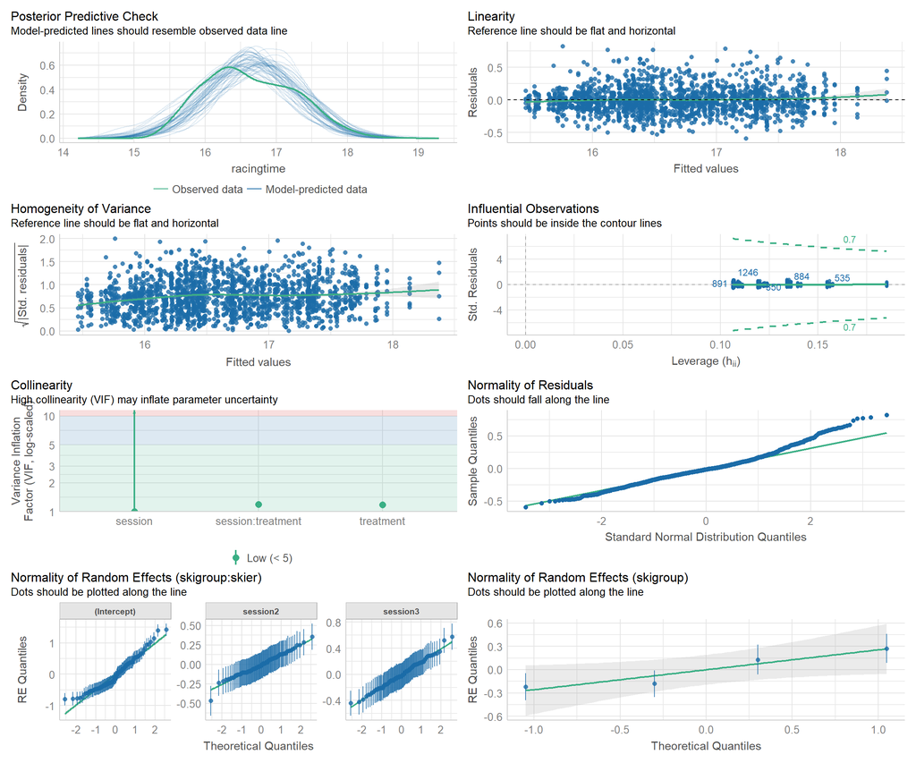

```r
summary(model_racingtime_acquisition_2)
```

```
Linear mixed model fit by maximum likelihood . t-tests use Satterthwaite's
  method [lmerModLmerTest]
Formula: racingtime ~ session * treatment + (1 | skigroup) + (1 + session |
    skigroup:skier)
   Data: d_acquisition

     AIC      BIC   logLik deviance df.resid
   105.8    199.6    -35.9     71.8     1823

Scaled residuals:
    Min      1Q  Median      3Q     Max
-2.8717 -0.5697 -0.0574  0.4879  4.0088

Random effects:
 Groups         Name        Variance Std.Dev. Corr
 skigroup:skier (Intercept) 0.26248  0.5123
                session2    0.02392  0.1547   -0.03
                session3    0.04821  0.2196    0.23  0.73
 skigroup       (Intercept) 0.05162  0.2272
 Residual                   0.04210  0.2052
Number of obs: 1840, groups:  skigroup:skier, 96; skigroup, 4

Fixed effects:
                    Estimate Std. Error       df t value             Pr(>|t|)
(Intercept)         16.61971    0.12526  3.92870 132.679         0.0000000254
session2            -0.39391    0.01960 92.32102 -20.092 < 0.0000000000000002
session3            -0.39758    0.02525 95.88738 -15.743 < 0.0000000000000002
treatment2           0.13585    0.13006 85.81893   1.044               0.2992
treatment3           0.14261    0.13006 85.81237   1.097               0.2759
session2:treatment2  0.07817    0.04843 92.49993   1.614               0.1099
session3:treatment2  0.14092    0.06233 95.74261   2.261               0.0260
session2:treatment3 -0.12462    0.04833 91.77718  -2.578               0.0115
session3:treatment3  0.01603    0.06232 95.65072   0.257               0.7976

(Intercept)         ***
session2            ***
session3            ***
treatment2
treatment3
session2:treatment2
session3:treatment2 *
session2:treatment3 *
session3:treatment3
---
Signif. codes:  0 '***' 0.001 '**' 0.01 '*' 0.05 '.' 0.1 ' ' 1

Correlation of Fixed Effects:
            (Intr) sessn2 sessn3 trtmn2 trtmn3 sss2:2 sss3:2 sss2:3
session2    -0.008
session3     0.086  0.637
treatment2  -0.014  0.000 -0.008
treatment3  -0.014  0.000 -0.008  0.526
sssn2:trtm2  0.000 -0.035 -0.022 -0.020 -0.010
sssn3:trtm2 -0.004 -0.022 -0.036  0.205  0.108  0.637
sssn2:trtm3  0.000 -0.038 -0.024 -0.010 -0.019  0.522  0.333
sssn3:trtm3 -0.003 -0.024 -0.037  0.108  0.206  0.332  0.522  0.637
```

We extract the relevant test statistics and turn them into a tibble

```r
model_racingtime_acquisition_2_tibble <- tidy(model_racingtime_acquisition_2, conf.int = TRUE) |>
  filter(term == "session2:treatment2" | term == "session3:treatment2" | term == "session2:treatment3" |  term == "session3:treatment3") |>
  mutate(term = str_replace_all(term, ":", "_x_"))

model_racingtime_acquisition_2_tibble
```

```
# A tibble: 4 × 10
  effect group term          estimate std.error statistic    df p.value conf.low
  <chr>  <chr> <chr>            <dbl>     <dbl>     <dbl> <dbl>   <dbl>    <dbl>
1 fixed  <NA>  session2_x_t…   0.0782    0.0484     1.61   92.5  0.110   -0.0180
2 fixed  <NA>  session3_x_t…   0.141     0.0623     2.26   95.7  0.0260   0.0172
3 fixed  <NA>  session2_x_t…  -0.125     0.0483    -2.58   91.8  0.0115  -0.221
4 fixed  <NA>  session3_x_t…   0.0160    0.0623     0.257  95.7  0.798   -0.108
# ℹ 1 more variable: conf.high <dbl>
```

We extract the estimated marginal means using the emmeans package

```r
emm_model_racingtime_acquisition_2_tibble <- emmeans(model_racingtime_acquisition_2, specs = ~ treatment * session, lmer.df="satterthwaite", infer = c(TRUE, FALSE)) |> as_tibble()

emm_model_racingtime_acquisition_2_tibble
```

```
# A tibble: 9 × 7
  treatment session emmean    SE    df lower.CL upper.CL
  <fct>     <fct>    <dbl> <dbl> <dbl>    <dbl>    <dbl>
1 rl        block1    16.8 0.148  7.45     16.5     17.1
2 slfc      block1    16.9 0.145  6.95     16.5     17.2
3 slts      block1    17.0 0.145  6.94     16.6     17.3
4 rl        block2    16.4 0.146  7.36     16.1     16.8
5 slfc      block2    16.6 0.144  6.86     16.2     16.9
6 slts      block2    16.5 0.144  6.85     16.1     16.8
7 rl        block3    16.4 0.153  8.96     16.0     16.7
8 slfc      block3    16.6 0.150  8.26     16.2     16.9
9 slts      block3    16.5 0.150  8.26     16.2     16.9
```

We create latex files of these statistics with the following custom function

```r
emm_model_racingtime_acquisition_2_tibble_block1 <- filter(emm_model_racingtime_acquisition_2_tibble, session == "block1")


write_emmeans_lmer <- function(model_output, model_name) {
  model_name <- as.character(model_name)

  # Create the folder if it doesn't exist
  folder_path <- "../../latex/statistics/marginalmeans"
  if (!dir.exists(folder_path)) {
    dir.create(folder_path)
  }

  # Loop over every row in d_emmean
  for (i in 1:nrow(model_output)) {
    row <- model_output[i, ]

    term <- as.character(row$treatment)
    session <- as.character(row$session)

    beta <- round(row$emmean, digits = 2)

    filename <- file.path(folder_path, paste("emmean_", model_name, "_", term, "_", session,".tex"))
    filename <- gsub(" ", "", filename, fixed = TRUE)
    cat(as.character(beta), file = filename)
  }
}

write_emmeans_lmer(emm_model_racingtime_acquisition_2_tibble_block1, "racingtimes_acquisition")
```

We fit nested models

```r
model_racingtime_acquisition_2_n1 <- lmer(racingtime ~ session / treatment + (1  | skigroup) + (1 + session | skigroup:skier), REML=FALSE, data=d_acquisition)

summary(model_racingtime_acquisition_2_n1)
```

```
Linear mixed model fit by maximum likelihood . t-tests use Satterthwaite's
  method [lmerModLmerTest]
Formula: racingtime ~ session/treatment + (1 | skigroup) + (1 + session |
    skigroup:skier)
   Data: d_acquisition

     AIC      BIC   logLik deviance df.resid
   105.8    199.6    -35.9     71.8     1823

Scaled residuals:
    Min      1Q  Median      3Q     Max
-2.8717 -0.5697 -0.0574  0.4879  4.0088

Random effects:
 Groups         Name        Variance Std.Dev. Corr
 skigroup:skier (Intercept) 0.26247  0.5123
                session2    0.02393  0.1547   -0.03
                session3    0.04821  0.2196    0.23  0.73
 skigroup       (Intercept) 0.05162  0.2272
 Residual                   0.04210  0.2052
Number of obs: 1840, groups:  skigroup:skier, 96; skigroup, 4

Fixed effects:
                         Estimate Std. Error       df t value
(Intercept)              16.61971    0.12526  3.92889 132.681
session2                 -0.39391    0.01961 92.31913 -20.092
session3                 -0.39758    0.02525 95.88772 -15.743
sessionblock1:treatment2  0.06282    0.13041 92.72654   0.482
sessionblock2:treatment2  0.14099    0.12752 86.15267   1.106
sessionblock3:treatment2  0.20373    0.14266 77.99751   1.428
sessionblock1:treatment3  0.17881    0.13039 92.66295   1.371
sessionblock2:treatment3  0.05419    0.12750 86.11780   0.425
sessionblock3:treatment3  0.19484    0.14267 78.02323   1.366
                                     Pr(>|t|)
(Intercept)                      0.0000000254 ***
session2                 < 0.0000000000000002 ***
session3                 < 0.0000000000000002 ***
sessionblock1:treatment2                0.631
sessionblock2:treatment2                0.272
sessionblock3:treatment2                0.157
sessionblock1:treatment3                0.174
sessionblock2:treatment3                0.672
sessionblock3:treatment3                0.176
---
Signif. codes:  0 '***' 0.001 '**' 0.01 '*' 0.05 '.' 0.1 ' ' 1

Correlation of Fixed Effects:
            (Intr) sessn2 sessn3 sss1:2 sss2:2 sss3:2 sss1:3 sss2:3
session2    -0.008
session3     0.086  0.637
sssnblck1:2 -0.014  0.008  0.000
sssnblck2:2 -0.014 -0.005 -0.008  0.930
sssnblck3:2 -0.014 -0.002 -0.016  0.900  0.941
sssnblck1:3 -0.014  0.009  0.001  0.526  0.489  0.473
sssnblck2:3 -0.014 -0.006 -0.008  0.489  0.526  0.495  0.930
sssnblck3:3 -0.014 -0.002 -0.015  0.473  0.495  0.525  0.900  0.941
```

We extract the relevant estimates from this nested model

```r
model_racingtime_acquisition_2_n1_tibble <- tidy(model_racingtime_acquisition_2_n1, conf.int = TRUE) |>
  filter(term == "sessionblock1:treatment2" | term == "sessionblock1:treatment3") |>
  mutate(term = str_replace_all(term, ":", "_simple_"))
model_racingtime_acquisition_2_n1_tibble
```

```
# A tibble: 2 × 10
  effect group term          estimate std.error statistic    df p.value conf.low
  <chr>  <chr> <chr>            <dbl>     <dbl>     <dbl> <dbl>   <dbl>    <dbl>
1 fixed  <NA>  sessionblock…   0.0628     0.130     0.482  92.7   0.631  -0.196
2 fixed  <NA>  sessionblock…   0.179      0.130     1.37   92.7   0.174  -0.0801
# ℹ 1 more variable: conf.high <dbl>
```

```r
model_racingtime_acquisition_2_n2 <- lmer(racingtime ~ treatment / session + (1  | skigroup) + (1 + session | skigroup:skier), REML=FALSE, data=d_acquisition)

summary(model_racingtime_acquisition_2_n2 )
```

```
Linear mixed model fit by maximum likelihood . t-tests use Satterthwaite's
  method [lmerModLmerTest]
Formula: racingtime ~ treatment/session + (1 | skigroup) + (1 + session |
    skigroup:skier)
   Data: d_acquisition

     AIC      BIC   logLik deviance df.resid
   105.8    199.6    -35.9     71.8     1823

Scaled residuals:
    Min      1Q  Median      3Q     Max
-2.8717 -0.5697 -0.0574  0.4879  4.0088

Random effects:
 Groups         Name        Variance Std.Dev. Corr
 skigroup:skier (Intercept) 0.26246  0.5123
                session2    0.02392  0.1547   -0.03
                session3    0.04821  0.2196    0.23  0.73
 skigroup       (Intercept) 0.05161  0.2272
 Residual                   0.04210  0.2052
Number of obs: 1840, groups:  skigroup:skier, 96; skigroup, 4

Fixed effects:
                       Estimate Std. Error       df t value
(Intercept)            16.61971    0.12526  3.92961 132.686
treatment2              0.13585    0.13006 85.82948   1.045
treatment3              0.14261    0.13005 85.82293   1.097
treatmentrl:session2   -0.37843    0.03497 91.63222 -10.823
treatmentslfc:session2 -0.30026    0.03351 93.47227  -8.960
treatmentslts:session2 -0.50305    0.03337 91.94965 -15.075
treatmentrl:session3   -0.44989    0.04504 95.16432  -9.988
treatmentslfc:session3 -0.30898    0.04309 96.38917  -7.171
treatmentslts:session3 -0.43387    0.04306 96.19562 -10.075
                                   Pr(>|t|)
(Intercept)              0.0000000253024912 ***
treatment2                            0.299
treatment3                            0.276
treatmentrl:session2   < 0.0000000000000002 ***
treatmentslfc:session2   0.0000000000000311 ***
treatmentslts:session2 < 0.0000000000000002 ***
```

[output cut: 10 more lines]

```
trtmntrl:s2 -0.005  0.014  0.014
trtmntslf:2 -0.005 -0.014  0.000  0.000
trtmntslt:2 -0.005  0.000 -0.014  0.000     0.000
trtmntrl:s3  0.052 -0.149 -0.149  0.636     0.000       0.000
trtmntslf:3  0.049  0.141  0.000  0.000     0.638       0.000       0.000
trtmntslt:3  0.049  0.000  0.142  0.000     0.000       0.637       0.000
            trtmntslf:3
treatment2
treatment3
trtmntrl:s2
trtmntslf:2
trtmntslt:2
trtmntrl:s3
trtmntslf:3
trtmntslt:3  0.000
```

We extract the relevant estimates from this nested model

```r
model_racingtime_acquisition_2_n2_tibble <- tidy(model_racingtime_acquisition_2_n2, conf.int = TRUE)

model_racingtime_acquisition_2_n2_tibble <- model_racingtime_acquisition_2_n2_tibble |>
  filter(term == "treatmentrl:session2" | term == "treatmentslfc:session2" | term == "treatmentslts:session2" |  term == "treatmentrl:session3" |  term ==  "treatmentslfc:session3" |  term ==  "treatmentslts:session3") |>
  mutate(term = str_replace_all(term, ":", "_x_"))


model_racingtime_acquisition_2_n2_tibble
```

```
# A tibble: 6 × 10
  effect group term         estimate std.error statistic    df  p.value conf.low
  <chr>  <chr> <chr>           <dbl>     <dbl>     <dbl> <dbl>    <dbl>    <dbl>
1 fixed  <NA>  treatmentrl…   -0.378    0.0350    -10.8   91.6 4.54e-18   -0.448
2 fixed  <NA>  treatmentsl…   -0.300    0.0335     -8.96  93.5 3.11e-14   -0.367
3 fixed  <NA>  treatmentsl…   -0.503    0.0334    -15.1   91.9 1.38e-26   -0.569
4 fixed  <NA>  treatmentrl…   -0.450    0.0450     -9.99  95.2 1.72e-16   -0.539
5 fixed  <NA>  treatmentsl…   -0.309    0.0431     -7.17  96.4 1.52e-10   -0.394
6 fixed  <NA>  treatmentsl…   -0.434    0.0431    -10.1   96.2 1.01e-16   -0.519
# ℹ 1 more variable: conf.high <dbl>
```

We combine the relevant estimates to a tibble

```r
model_racingtime_acquisition_estimates <- rbind(model_racingtime_acquisition_2_n1_tibble,model_racingtime_acquisition_2_n2_tibble)

model_racingtime_acquisition_estimates
```

```
# A tibble: 8 × 10
  effect group term         estimate std.error statistic    df  p.value conf.low
  <chr>  <chr> <chr>           <dbl>     <dbl>     <dbl> <dbl>    <dbl>    <dbl>
1 fixed  <NA>  sessionbloc…   0.0628    0.130      0.482  92.7 6.31e- 1  -0.196
2 fixed  <NA>  sessionbloc…   0.179     0.130      1.37   92.7 1.74e- 1  -0.0801
3 fixed  <NA>  treatmentrl…  -0.378     0.0350   -10.8    91.6 4.54e-18  -0.448
4 fixed  <NA>  treatmentsl…  -0.300     0.0335    -8.96   93.5 3.11e-14  -0.367
5 fixed  <NA>  treatmentsl…  -0.503     0.0334   -15.1    91.9 1.38e-26  -0.569
6 fixed  <NA>  treatmentrl…  -0.450     0.0450    -9.99   95.2 1.72e-16  -0.539
7 fixed  <NA>  treatmentsl…  -0.309     0.0431    -7.17   96.4 1.52e-10  -0.394
8 fixed  <NA>  treatmentsl…  -0.434     0.0431   -10.1    96.2 1.01e-16  -0.519
# ℹ 1 more variable: conf.high <dbl>
```

We write these estimates to latex code with the following custom function

```r
write_beta_lmer <- function(model_output, model_name) {
  model_name <- as.character(model_name)

  # Create the folder if it doesn't exist
  folder_path <- "../../latex/statistics/beta"
  if (!dir.exists(folder_path)) {
    dir.create(folder_path)
  }

  # Loop over every row in d_emmean
  for (i in 1:nrow(model_output)) {
    row <- model_output[i, ]

    term <- as.character(row$term)

    beta <- round(row$estimate, digits = 2)

    filename <- file.path(folder_path, paste("beta_", model_name, "_", term, ".tex"))
    filename <- gsub(" ", "", filename, fixed = TRUE)
    cat(as.character(beta), file = filename)
  }
}
```

```r
write_beta_lmer(model_racingtime_acquisition_estimates, "racingtimes_acquisition")
```

We combine the relevant test statistic into a single tibble

```r
model_racingtime_acquisition_combined <- rbind(model_racingtime_acquisition_2_tibble, model_racingtime_acquisition_2_n1_tibble)
model_racingtime_acquisition_combined
```

```
# A tibble: 6 × 10
  effect group term          estimate std.error statistic    df p.value conf.low
  <chr>  <chr> <chr>            <dbl>     <dbl>     <dbl> <dbl>   <dbl>    <dbl>
1 fixed  <NA>  session2_x_t…   0.0782    0.0484     1.61   92.5  0.110   -0.0180
2 fixed  <NA>  session3_x_t…   0.141     0.0623     2.26   95.7  0.0260   0.0172
3 fixed  <NA>  session2_x_t…  -0.125     0.0483    -2.58   91.8  0.0115  -0.221
4 fixed  <NA>  session3_x_t…   0.0160    0.0623     0.257  95.7  0.798   -0.108
5 fixed  <NA>  sessionblock…   0.0628    0.130      0.482  92.7  0.631   -0.196
6 fixed  <NA>  sessionblock…   0.179     0.130      1.37   92.7  0.174   -0.0801
# ℹ 1 more variable: conf.high <dbl>
```

We write the test statistics to latex code with the following function

```r
write_contrast_lmer <- function(model_output, model_name) {
  model_name <- as.character(model_name)

  # Create the folder if it doesn't exist
  folder_path <- "../../latex/statistics/contrasts"
  if (!dir.exists(folder_path)) {
    dir.create(folder_path)
  }

  p_value_writer <- function(p_value) {
    symbol <- ifelse(p_value > 0.001, " = ", " < ")
    p_value_format <- ifelse(p_value > 0.001, formatC(round(p_value, digits = 3), digits = 3, format = "f"), "0.001")
    write_p_value <- paste(symbol, p_value_format)
    return(write_p_value)
  }

  # Loop over every row in d_emmean
  for (i in 1:nrow(model_output)) {
    row <- model_output[i, ]

    term <- as.character(row$term)

    beta <- round(row$estimate, digits = 2)
    statistic <- round(row$statistic, digits = 2)
    df <- round(row$df, digits = 3)
    ci_low <- round(row$conf.low, digits = 2)
    ci_high <- round(row$conf.high, digits = 2)
    p_value <- row$p.value

    report <- paste("$\\beta$ =", beta,", 95\\% CI [",ci_low,", ", ci_high,"], $t$(", df, ") =", statistic,", $p$",p_value_writer(p_value))

    filename <- file.path(folder_path, paste("contrast_", model_name, "_", term, ".tex"))
    filename <- gsub(" ", "", filename, fixed = TRUE)
    cat(report, file = filename)
  }
}
```

```r
write_contrast_lmer(model_racingtime_acquisition_combined, "racingtimes_acquisition")
```

## Plot

```r
#Color scheme
colorPalette <- c("#DD1E88FF", "#1C8EB3FF", "#8FC344FF")

  # Theme
theme_racingtime <- ggplot2::theme(
    axis.text.y = element_text(size = 5),
    axis.text.x = element_text(size = 5),
    axis.title = element_text(size = 6),
    strip.text = element_text(size = 5, color = "black"),
    strip.background = element_blank(),
    plot.title = element_text(size = 7),
    panel.grid = element_blank(),
    panel.border = element_blank(),
   axis.line.x = element_line(),
   axis.line.y = element_line(),
    legend.position = "none"#,
    #legend.key.height= unit(0.2, 'cm'),
    #legend.key.width= unit(0.4, 'cm'),
    #legend.title = element_text(size=6),
    #legend.text = element_text(size=5)
  )


# The commented code below was used in case we wanted to plot a fitted line for each skier

# d_raw <- d_acquisition |>
#   group_by(skigroup, skier, session, treatment) |>
#   summarise(racingtime = mean(racingtime, na.rm=TRUE)) |>
#   mutate(skier_unique = interaction(skigroup, skier)) |>
#   ungroup()

# d_raw  <- d_raw  |>
#   mutate(skier_unique = interaction(skigroup, skier)) |>
#   mutate(session = as.numeric(sub("block", "", session)))

d_acquisition  <- d_acquisition    |>
  mutate(skier_unique = interaction(skigroup, skier)) #|>
  #mutate(session = as.numeric(sub("block", "", session)))

#emm_model_racingtime_acquisition_2_tibble  <- emm_model_racingtime_acquisition_2_tibble  %>%
#  mutate(session = as.numeric(sub("block", "", session)))
```

```r
dodge_width <- 0.3
point_size <- 2.5
line_size <- 0.6
quasi_dot_size <- 0.1
stroke_size <- 0.6
spread_width <- 0.05

plot_acquisition <- ggplot(data = d_acquisition, aes(x = session, color=treatment, y = racingtime, group = treatment)) +
  geom_quasirandom(width=spread_width, dodge.width = dodge_width, color="#dbe2e3", size=quasi_dot_size ) +
  geom_line(data = emm_model_racingtime_acquisition_2_tibble, aes(x = session, y = emmean),  size = 0.25, stroke = stroke_size, position=position_dodge(dodge_width)) +
  geom_linerange(data = emm_model_racingtime_acquisition_2_tibble, aes(x = session, y = emmean, color=treatment, ymin = lower.CL, ymax = upper.CL, fill = treatment), color = "black", pch = 21, size = line_size, stroke = stroke_size, position=position_dodge(dodge_width)) +
  geom_point(data = emm_model_racingtime_acquisition_2_tibble, aes(x = session, y = emmean, color=treatment, fill=treatment), pch = 21, size = point_size, color="black",stroke = stroke_size, position=position_dodge(dodge_width)) +
  scale_color_manual(values = colorPalette, guide = "none") +
  scale_fill_manual(values = colorPalette,name = "Treatment", labels=c('Reinforcement \n learning', 'Supervised \n (free choice)', 'Supervised \n (target skill)')) +
  scale_x_discrete(labels = c("Forced \n exploration", "Free choice 1", "Free choice 2")) +
  annotate("text", x = 1.5, y = 16.8, label = "*", family = "Arial", font = 2,  cex = 0.6) +
  annotate("text", x = 2.5, y = 16.6, label = "*", family = "Arial", font = 2,  cex = 0.6) +
  theme_bw() +
  theme_racingtime +
  labs(y = "Racing time (seconds)", x = NULL, title="Acquisition")


ggsave("test.svg", width=8, height=8, unit="cm")
```

# Retention and transfer

## Select data and calculate average performance on baseline

The first thing we do is to calculate the average performance at baseline for each skier nested within skigroup. We create a new tibble that holds this average, which we later attach to the original tibble.

```r
# Filter baseline, retention and transfer
d_retention_and_transfer <- filter(d, session == "baseline" | session == "retention" | session == "transfer")

d_retention_and_transfer <-  select(d_retention_and_transfer , skigroup, skier, session, treatment, trial, racingtime)

baseline_avg <- d_retention_and_transfer  |>
  filter(session == "baseline") |>
  group_by(skigroup, skier) |>
  summarise(avg_baseline = round(mean(racingtime, na.rm = TRUE), digits=2)) |>
  ungroup()

baseline_avg
```

```
# A tibble: 96 × 3
   skigroup skier avg_baseline
   <chr>    <dbl>        <dbl>
 1 a            1         16.0
 2 a            2         16.4
 3 a            3         16.5
 4 a            4         16.5
 5 a            5         16.2
 6 a            6         17.0
 7 a            7         17.2
 8 a            8         17.6
 9 a            9         17.1
10 a           10         16.4
# ℹ 86 more rows
```

`avg_baseline` in the `baseline_avg` tibble is a column that holds the average racing time for each skier in the dataset. We can now join two tibbles with `left_join`

```r
d_retention_and_transfer  <- d_retention_and_transfer |>
  left_join(baseline_avg, by = c("skigroup", "skier"))

d_retention_and_transfer
```

```
# A tibble: 1,147 × 7
   skigroup skier session   treatment trial racingtime avg_baseline
   <chr>    <dbl> <chr>     <chr>     <dbl>      <dbl>        <dbl>
 1 a            1 baseline  slfc          1       15.8         16.0
 2 a            1 baseline  slfc          2       16.2         16.0
 3 a            1 baseline  slfc          3       16.1         16.0
 4 a            1 baseline  slfc          4       16.1         16.0
 5 a            1 retention slfc         25       15.7         16.0
 6 a            1 retention slfc         26       15.9         16.0
 7 a            1 retention slfc         27       15.9         16.0
 8 a            1 retention slfc         28       NA           16.0
 9 a            1 transfer  slfc         29       16.0         16.0
10 a            1 transfer  slfc         30       15.8         16.0
# ℹ 1,137 more rows
```

```r
# Filter baseline, retention and transfer
d_retention_and_transfer <- filter(d_retention_and_transfer, session != "baseline")
d_retention_and_transfer
```

```
# A tibble: 763 × 7
   skigroup skier session   treatment trial racingtime avg_baseline
   <chr>    <dbl> <chr>     <chr>     <dbl>      <dbl>        <dbl>
 1 a            1 retention slfc         25       15.7         16.0
 2 a            1 retention slfc         26       15.9         16.0
 3 a            1 retention slfc         27       15.9         16.0
 4 a            1 retention slfc         28       NA           16.0
 5 a            1 transfer  slfc         29       16.0         16.0
 6 a            1 transfer  slfc         30       15.8         16.0
 7 a            1 transfer  slfc         31       16.1         16.0
 8 a            1 transfer  slfc         32       15.9         16.0
 9 a            2 retention slfc         25       16.1         16.4
10 a            2 retention slfc         26       16.5         16.4
# ℹ 753 more rows
```

## Coding contrasts

The next step is to set up the treatment contrasts. Instead of using the Intercept as the reference level, we code the Intercept to represent the Grand Mean. This coding scheme is known as simple coding (https://stats.oarc.ucla.edu/r/library/r-library-contrast-coding-systems-for-categorical-variables/).”

```r
# Contrast session (two levels)
d_retention_and_transfer$session <- as.factor(d_retention_and_transfer$session)
treatmentcoding <- contr.treatment(2)
matrix <- matrix(rep(1/2, 2), ncol=1)
treatment_simplecoded <- treatmentcoding - matrix
contrasts(d_retention_and_transfer$session) <- treatment_simplecoded

# Contrast treatment (three levels)
d_retention_and_transfer$treatment <- as.factor(d_retention_and_transfer$treatment)
treatmentcoding <- contr.treatment(3)
matrix <- matrix(rep(1/3, 6), ncol=2)
treatment_simplecoded <- treatmentcoding - matrix
contrasts(d_retention_and_transfer$treatment) <- treatment_simplecoded
```

## Models

```r
model_racingtime_retention_and_transfer_n1 <- lmer(racingtime ~
                                                     avg_baseline + # Baseline as a covariate
                                                     session * treatment +
                                                     (1 | skigroup/skier),
                                                   REML=FALSE,
                                                   data=d_retention_and_transfer)

anova(model_racingtime_retention_and_transfer_n1)
```

```
Type III Analysis of Variance Table with Satterthwaite's method
                  Sum Sq Mean Sq NumDF  DenDF  F value                Pr(>F)
avg_baseline      7.2275  7.2275     1  95.23 418.7637 < 0.00000000000000022
session           4.7437  4.7437     1 641.80 274.8489 < 0.00000000000000022
treatment         0.0697  0.0349     2  92.01   2.0195              0.138563
session:treatment 0.1809  0.0904     2 641.76   5.2405              0.005527

avg_baseline      ***
session           ***
treatment
session:treatment **
---
Signif. codes:  0 '***' 0.001 '**' 0.01 '*' 0.05 '.' 0.1 ' ' 1
```

```r
summary(model_racingtime_retention_and_transfer_n1)
```

```
Linear mixed model fit by maximum likelihood . t-tests use Satterthwaite's
  method [lmerModLmerTest]
Formula: racingtime ~ avg_baseline + session * treatment + (1 | skigroup/skier)
   Data: d_retention_and_transfer

     AIC      BIC   logLik deviance df.resid
  -575.0   -529.0    297.5   -595.0      727

Scaled residuals:
    Min      1Q  Median      3Q     Max
-2.5480 -0.6356 -0.0772  0.5619  5.1078

Random effects:
 Groups         Name        Variance Std.Dev.
 skier:skigroup (Intercept) 0.04730  0.2175
 skigroup       (Intercept) 0.01653  0.1286
 Residual                   0.01726  0.1314
Number of obs: 737, groups:  skier:skigroup, 96; skigroup, 4

Fixed effects:
                      Estimate Std. Error         df t value
(Intercept)           2.663654   0.670128  95.742441   3.975
avg_baseline          0.814436   0.039799  95.228241  20.464
session2             -0.161594   0.009747 641.795085 -16.579
treatment2            0.110123   0.056339  92.091717   1.955
treatment3            0.035567   0.056323  92.168703   0.631
session2:treatment2  -0.024177   0.024138 641.953098  -1.002
session2:treatment3  -0.075877   0.024196 642.022768  -3.136
                                Pr(>|t|)
(Intercept)                     0.000137 ***
avg_baseline        < 0.0000000000000002 ***
session2            < 0.0000000000000002 ***
treatment2                      0.053656 .
treatment3                      0.529292
session2:treatment2             0.316899
session2:treatment3             0.001791 **
---
Signif. codes:  0 '***' 0.001 '**' 0.01 '*' 0.05 '.' 0.1 ' ' 1

Correlation of Fixed Effects:
            (Intr) avg_bs sessn2 trtmn2 trtmn3 sss2:2
avg_baselin -0.995
session2    -0.001  0.000
treatment2  -0.030  0.029  0.005
treatment3   0.005 -0.006  0.004  0.526
sssn2:trtm2  0.001  0.000 -0.061 -0.009 -0.008
sssn2:trtm3  0.001 -0.001 -0.057 -0.008 -0.010  0.536
```

```r
emm_model_racingtime_retention_and_transfer_n1 <- emmeans(model_racingtime_retention_and_transfer_n1, specs = ~ session * treatment, lmer.df="satterthwaite") |> as_tibble()

emm_model_racingtime_retention_and_transfer_n1
```

```
# A tibble: 6 × 7
  session   treatment emmean     SE    df lower.CL upper.CL
  <fct>     <fct>      <dbl>  <dbl> <dbl>    <dbl>    <dbl>
1 retention rl          16.3 0.0767  6.22     16.1     16.5
2 transfer  rl          16.2 0.0765  6.17     16.0     16.4
3 retention slfc        16.4 0.0756  5.87     16.2     16.6
4 transfer  slfc        16.3 0.0756  5.86     16.1     16.5
5 retention slts        16.4 0.0756  5.88     16.2     16.6
6 transfer  slts        16.2 0.0756  5.87     16.0     16.4
```

```r
model_racingtime_retention_and_transfer_n2 <- lmer(racingtime ~
                                                     avg_baseline + # Baseline as a covariate
                                                     session / treatment +
                                                     (1 | skigroup/skier),
                                                   REML=FALSE,
                                                   data=d_retention_and_transfer)

anova(model_racingtime_retention_and_transfer_n2)
```

```
Type III Analysis of Variance Table with Satterthwaite's method
                  Sum Sq Mean Sq NumDF  DenDF  F value                Pr(>F)
avg_baseline      7.2275  7.2275     1  95.23 418.7637 < 0.00000000000000022
session           0.9068  0.9068     1 642.54  52.5418     0.000000000001213
session:treatment 0.2497  0.0624     4 159.82   3.6166              0.007508

avg_baseline      ***
session           ***
session:treatment **
---
Signif. codes:  0 '***' 0.001 '**' 0.01 '*' 0.05 '.' 0.1 ' ' 1
```

```r
summary(model_racingtime_retention_and_transfer_n2)
```

```
Linear mixed model fit by maximum likelihood . t-tests use Satterthwaite's
  method [lmerModLmerTest]
Formula: racingtime ~ avg_baseline + session/treatment + (1 | skigroup/skier)
   Data: d_retention_and_transfer

     AIC      BIC   logLik deviance df.resid
  -575.0   -529.0    297.5   -595.0      727

Scaled residuals:
    Min      1Q  Median      3Q     Max
-2.5480 -0.6356 -0.0772  0.5619  5.1078

Random effects:
 Groups         Name        Variance Std.Dev.
 skier:skigroup (Intercept) 0.04730  0.2175
 skigroup       (Intercept) 0.01653  0.1286
 Residual                   0.01726  0.1314
Number of obs: 737, groups:  skier:skigroup, 96; skigroup, 4

Fixed effects:
                              Estimate Std. Error         df t value
(Intercept)                   2.663654   0.670128  95.742503   3.975
avg_baseline                  0.814436   0.039799  95.228309  20.464
session2                     -0.161594   0.009747 641.795085 -16.579
sessionretention:treatment2   0.122212   0.057723 101.422404   2.117
sessiontransfer:treatment2    0.098035   0.057511  99.979185   1.705
sessionretention:treatment3   0.073505   0.057725 101.629930   1.273
sessiontransfer:treatment3   -0.002372   0.057491 100.033066  -0.041
                                        Pr(>|t|)
(Intercept)                             0.000137 ***
avg_baseline                < 0.0000000000000002 ***
session2                    < 0.0000000000000002 ***
sessionretention:treatment2             0.036687 *
sessiontransfer:treatment2              0.091370 .
sessionretention:treatment3             0.205791
sessiontransfer:treatment3              0.967178
---
Signif. codes:  0 '***' 0.001 '**' 0.01 '*' 0.05 '.' 0.1 ' ' 1

Correlation of Fixed Effects:
            (Intr) avg_bs sessn2 sssnr:2 sssnt:2 sssnr:3
avg_baselin -0.995
session2    -0.001  0.000
sssnrtntn:2 -0.029  0.028  0.018
sssntrnsf:2 -0.029  0.028 -0.008  0.912
sssnrtntn:3  0.005 -0.006  0.016  0.528   0.479
sssntrnsf:3  0.005 -0.006 -0.008  0.480   0.526   0.912
```

```r
model_racingtime_retention_and_transfer_n2_tibble <- tidy(model_racingtime_retention_and_transfer_n2, conf.int = TRUE)

model_racingtime_retention_and_transfer_n2_tibble <- model_racingtime_retention_and_transfer_n2_tibble |>
  filter(term == "sessionretention:treatment2" | term == "sessiontransfer:treatment2" | term == "sessionretention:treatment3" |  term == "sessiontransfer:treatment3") |>
  mutate(term = str_replace_all(term, ":", "_x_"))


model_racingtime_retention_and_transfer_n2_tibble
```

```
# A tibble: 4 × 10
  effect group term          estimate std.error statistic    df p.value conf.low
  <chr>  <chr> <chr>            <dbl>     <dbl>     <dbl> <dbl>   <dbl>    <dbl>
1 fixed  <NA>  sessionreten…  0.122      0.0577    2.12    101.  0.0367  0.00771
2 fixed  <NA>  sessiontrans…  0.0980     0.0575    1.70    100.  0.0914 -0.0161
3 fixed  <NA>  sessionreten…  0.0735     0.0577    1.27    102.  0.206  -0.0410
4 fixed  <NA>  sessiontrans… -0.00237    0.0575   -0.0413  100.  0.967  -0.116
# ℹ 1 more variable: conf.high <dbl>
```

## Plot

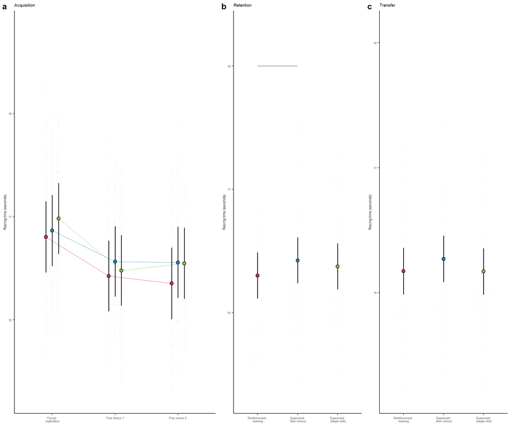

```r
plot_grid(plot_acquisition,plot_retention,plot_transfer, axis="lr", align="vh", ncol=3, labels = "auto", rel_widths = c(1.5, 1, 1))
```

```r
#ggsave("test2.svg", device="svg", height=8, width=16, units="cm")
```

# Strategies

```
# A tibble: 2,299 × 16
   skigroup skier treatment session trial strategy best_strategy_first
   <chr>    <dbl> <chr>     <chr>   <dbl> <chr>    <chr>
 1 a            1 slfc      block1      5 a        d
 2 a            1 slfc      block1      6 c        d
 3 a            1 slfc      block1      7 b        d
 4 a            1 slfc      block1      8 d        d
 5 a            1 slfc      block1      9 d        d
 6 a            1 slfc      block1     10 c        d
 7 a            1 slfc      block1     11 b        d
 8 a            1 slfc      block1     12 a        d
 9 a            1 slfc      block2     13 c        d
10 a            1 slfc      block2     14 c        d
# ℹ 2,289 more rows
# ℹ 9 more variables: best_strategy_last <chr>, theory_best <chr>,
#   racingtime <dbl>, chose_best_strategy <dbl>, chose_theoretical_best <dbl>,
#   regret_a <dbl>, regret_b <dbl>, regret_c <dbl>, regret_d <dbl>
```

```
Linear mixed model fit by maximum likelihood . t-tests use Satterthwaite's
  method [lmerModLmerTest]
Formula: racingtime ~ session + strategy * treatment + (1 | skigroup) +
    (1 + session | skigroup:skier)
   Data: d_strategies

     AIC      BIC   logLik deviance df.resid
  -992.1   -838.3    523.1  -1046.1     2172

Scaled residuals:
    Min      1Q  Median      3Q     Max
-4.1668 -0.5492 -0.0228  0.5148  4.5152

Random effects:
 Groups         Name             Variance Std.Dev. Corr
 skigroup:skier (Intercept)      0.27165  0.5212
                sessionblock2    0.03263  0.1806   -0.26
                sessionblock3    0.04707  0.2170    0.02  0.65
                sessionretention 0.03071  0.1752   -0.14  0.59  0.68
 skigroup       (Intercept)      0.03672  0.1916
 Residual                        0.02340  0.1530
Number of obs: 2199, groups:  skigroup:skier, 96; skigroup, 4

Fixed effects:
                       Estimate Std. Error         df t value
(Intercept)            16.88189    0.10985    3.65365 153.675
sessionblock2          -0.25144    0.02119  106.67312 -11.867
sessionblock3          -0.25118    0.02449  106.90847 -10.256
sessionretention       -0.33907    0.02125  109.63525 -15.958
strategy2              -0.41026    0.01400 1845.09422 -29.311
strategy3              -0.20536    0.01473 1830.71440 -13.946
strategy4              -0.42404    0.01397 1879.36472 -30.343
treatment2              0.02804    0.12485   92.06249   0.225
treatment3              0.02959    0.12506   92.76170   0.237
strategy2:treatment2    0.17370    0.03238 1916.24847   5.365
strategy3:treatment2    0.06998    0.03511 1852.22019   1.993
strategy4:treatment2    0.07761    0.03235 1930.34575   2.399
strategy2:treatment3    0.03284    0.03548 1881.67049   0.925
strategy3:treatment3    0.01201    0.03722 1829.97543   0.323
strategy4:treatment3   -0.03250    0.03431 1897.12324  -0.947
                                 Pr(>|t|)
(Intercept)                  0.0000000427 ***
sessionblock2        < 0.0000000000000002 ***
sessionblock3        < 0.0000000000000002 ***
sessionretention     < 0.0000000000000002 ***
strategy2            < 0.0000000000000002 ***
strategy3            < 0.0000000000000002 ***
strategy4            < 0.0000000000000002 ***
treatment2                         0.8228
treatment3                         0.8135
strategy2:treatment2         0.0000000907 ***
strategy3:treatment2               0.0464 *
strategy4:treatment2               0.0165 *
strategy2:treatment3               0.3548
strategy3:treatment3               0.7471
strategy4:treatment3               0.3436
---
Signif. codes:  0 '***' 0.001 '**' 0.01 '*' 0.05 '.' 0.1 ' ' 1
```

```
# A tibble: 48 × 8
   session   strategy treatment emmean    SE    df lower.CL upper.CL
   <fct>     <fct>    <fct>      <dbl> <dbl> <dbl>    <dbl>    <dbl>
 1 block1    a        rl          17.2 0.134  8.10     16.8     17.5
 2 block2    a        rl          16.9 0.134  8.11     16.6     17.2
 3 block3    a        rl          16.9 0.136  8.81     16.6     17.2
 4 retention a        rl          16.8 0.135  8.25     16.5     17.1
 5 block1    b        rl          16.7 0.133  7.87     16.4     17.0
 6 block2    b        rl          16.4 0.132  7.80     16.1     16.7
 7 block3    b        rl          16.4 0.135  8.48     16.1     16.7
 8 retention b        rl          16.3 0.133  7.93     16.0     16.6
 9 block1    c        rl          16.9 0.134  7.98     16.6     17.2
10 block2    c        rl          16.7 0.133  7.96     16.4     17.0
# ℹ 38 more rows
```

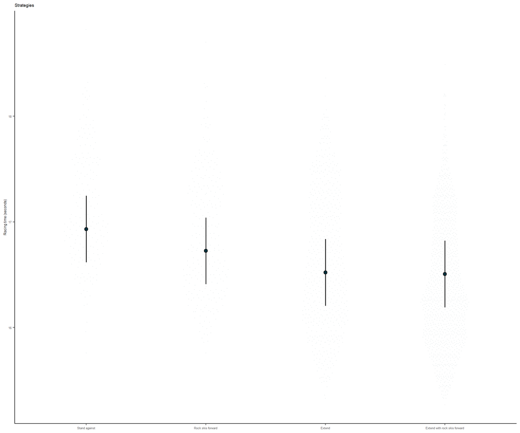